# MeshingNet: A New Mesh Generation Method based on Deep Learning

### Zheyan Zhang, Yongxing Wang, Peter K. Jimack and He Wang

##### Implementación: Arturo Rodriguez - da.rodriguezh@uniandes.edu.co

Para ejecutar este notebook es necesario contar con las librerias, se incluye el comando de instalación con pip:

- TensorFlow `>>>pip install tensorflow --user`
- TensorFlow Docs `>>>pip install git+https://github.com/tensorflow/docs`
- Numpy `>>>pip install numpy --user`
- Matplotlib `>>>pip install matplotlib --user`
- Pandas `>>>pip install pandas --user`
- Seaborn `>>>pip install seaborn --user`
- FEMSections (Libreria propia) `>>>pip install FEMSections --user`
- Triangle `>>>pip install triangle --user`
- Pydoty (opcional) `>>>pip install pydot --user`
- Graphviz (opcional)`>>>pip install graphviz --user` Requiere instalacion de graphviz y agregar como variable de entorno

### Advertencias

1. La creación del dataset es un proceso costoso, por ende se provee de una alternativa al momento de crearlo
2. Se tiene un dataset de pequeño (aprox 84000 datos) tamaño en la carpeta data adjunta con este documento, puede usarse para realizar una evaluacion preliminar del modelo
3. Los procesos graficos de elementos finitos suelenser lentos y ocupan una gran cantidad de memoria, por lo tanto, en cada metodo o funcion que pueda llegar a realizar una grafica se tiene un parametro `plot` el cual por defecto es `True`. Si no se requiere graficar, puede establecerse este parametro en `False`

El siguiente codigo esta basado en el artículo *MeshingNet: A New Mesh Generation Method based on Deep Learning* (Zhang, 2020). Este articulo puede descargarse gratuitamente desde arXiv: https://arxiv.org/abs/2004.07016.

El codigo tiene un propósito académico para futuras investigaciones

# 0. Imports

```python
#Variables globales del modelo:
DIBUJAR_MODELOS = True
import os

import numpy as np
import matplotlib.pyplot as plt
import pandas as pd
import seaborn as sns

import tensorflow as tf
from tensorflow import keras
from tensorflow.keras import layers
import tensorflow_docs as tfdocs
import tensorflow_docs.plots
import tensorflow_docs.modeling

import triangle as tr

try:
    from tensorflow.keras.utils import plot_model
    import pydot
    pydot.Dot.create(pydot.Dot())
except:
    DIBUJAR_MODELOS = False
    print('No se pudo importar pydot o graphviz, por lo tanto se mostraran resumenes de los modelos enluagr de graficos')

try:
    import FEMSections as FEM
    import FEMSections.FEM2D.Mesh as Mesh
    from FEMSections.FEM2D.Utils import *
    from FEMSections.FEM2D.Utils.error import *
except:
    raise Exception('No se encuentra la libreria FEMSections. Puede descargarse con el comando >>>pip install FEMSections --user\n'+
                   'Se puede tambien descargar desde Github: https://github.com/ZibraMax/FEMSections')
def mostrarModelo(model,**kargs):
    if DIBUJAR_MODELOS:
        return plot_model(model,**kargs)
    else:
        return model.summary()
def norm(x):
    return (x - train_stats['mean']) / train_stats['std']
print('Version de TensorFlow: ',tf.__version__)
PATH = os.getcwd()
```

```
Version de TensorFlow:  2.2.0
```

# 1. Dataset

La ecuación diferencial que se esta solucionando es: $$\nabla^2+2=0$$

Para integrar cada elemento e usan 7 puntos de gauss

## 1.1. Generación de datos

### Paso 1: Generación de poligono aleatorio

Para ello se usó un algoritmo que genera poligonos de manera aleatoria, este algoritmo se encuentra en FEMSections.FEMS2D.Utils (en la primera celda de codigo se importo la función, por lo tanto, puede usarse sin necesidad de usar la ruta completa). la función recibe los siguientes parámetros: `generatePolygon(ctrX=10, ctrY=10, aveRadius=5, irregularity=0.5, spikeyness=0.5, numVerts=6)`

```python
radio = 5
spk = np.random.random()
irre = np.random.random()
vert = 6
vertices = generatePolygon(ctrX=2*radio, ctrY=2*radio, aveRadius=radio, irregularity=irre, spikeyness=spk, numVerts=vert)

#En este caso se usará pandas para visualizar la saldia como tabla, sin embargo, esto no es necesario
pd.DataFrame(vertices, columns=["Coordenada X", "Coordenada Y"])
```

|  | Coordenada X | Coordenada Y |
| --- | --- | --- |
| 0 | 14 | 6 |
| 1 | 12 | 11 |
| 2 | 8 | 19 |
| 3 | 3 | 9 |
| 4 | 7 | 8 |
| 5 | 9 | 4 |

### Paso 2: Enmallado fino y enmallado grueso

Usando *Triangle* se encuentran las triangulaciones finas y gruesas para el mismo polígono. Para ello, se creo una función en el paquete Utils (igualquela funcion anterior) para facilitar dicho proceso. La funcion FEMSections.FEM2D.Utils.generarPares tiene los siguientes parámetros: `generarPares(geom=5,radio=5,vert=6,da1=3,da2=100,bcb=[0,1],value=10,plot=False)`

Los parámetros representan:

- geom: Número de triangulaciones a realizar, por defecto es 5.
- radio: Input para generar el dominio.
- vert: Numero de vertices de la geometría.
- da1: Divisior de area inicial
- da2: Divisior de area final
- bcb: Arreglo de bordes donde se aplicaran las condiciones de borde
- plot: Booleano para graficar la solucion

El area maxima del elemento se calcula como: $$A_e=\frac{R}{da_i}$$ Donde:

- $A_{emax}$: Area máxima del elemento
- $R$: Radio de la función `generatePolygon`
- $da_i$: Divisor de area, puede ser el divisor inicial o el divisor final

Se calculan dos areas maximas, la primera con el divisor incial y la segunda con el divisor final

Posteriormente se calculan las triangulaciones con cada una de esas areas y se construyen los problemas de elementos finitos con las condiciones de borde escenciales que se establecen por parámetro.

La funcion retorna un conjunto de pares FEMSections.FEM2D.FEM1V que tienen el problema de elementos finitos codificados en los atributos de la librería. Es decir, se retornan el numero de pares que se indique en el parámetro geom

### Paso 3: Solución de sistemas de ambos enmallados

Mediante NumPy se solucionan los sistemas de ecuaciones encontrando la matriz inversa de lamatriz de coeficientes

```
Integrando elementos [##################################################] 806/806
Ensamblando sistema de ecuaciones
Definiendo condiciones deborde
Solucionando sistema de ecuaciones
```

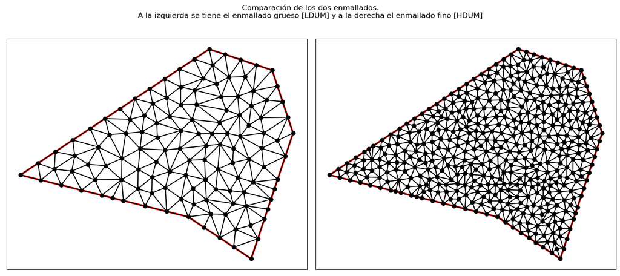

```python
ModeloL,ModeloH = generarPares(geom=1,radio=5,vert=6,da1=10,da2=40,bcb=[0,1],plot=False)[0]
tr.compare(plt,ModeloL.geometria.triangular,ModeloH.geometria.triangular,figsize=[14,7])
plt.suptitle('Comparación de los dos enmallados.\nA la izquierda se tiene el enmallado grueso [LDUM] y a la derecha el enmallado fino [HDUM]')
```

### Paso 4: Evaluación del error (L1)

Para encontrar la solucion en un punto especifico se usaron las funciones de interpolacion de elementos triangulares en coordenadas globales, ya que se pueden encontrar expresiones especificas para cada elementos, de esta manera se evita el uso del algoritmo de inverse mapping para encontrar la solución en un punto específico.

Este procedimiento se realiza para cada nodo del dominio del enmallado grueso

El error se calcula como:

$$E=\left|\frac{U_g-U_f}{U_f}\right|$$

La funcion `L1error` del modulo FEMSections.FEM2D.Utils realiza este procedimiento, esta funcion toma como parámetros el modelo de baja densidad y el modelo de alta densidad.

El error puede ser interpolado por medio de las funciones de interpolacion en los elementos, tratandolo como si fuera la solucion en los nodos.

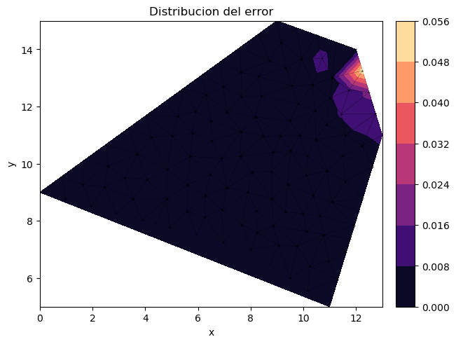

```python
errores,U,UG = L1error(ModeloL,ModeloH,plot=True)
```

### Paso 5: Corrección de areas en base al error

Para ello se usa el modelo de cooreccion propuesto por el paper donde el error es proporcional a una constante K un exponenete alfa, de tal manera, se calculó la nueva area como: $$A_e=min\left(\frac{K}{E_e^\alpha},A_{0}\right)$$

La función `areaCorrection` calcula las correcciones de area en los nodos y la función `areasRefinado` extrae el valor minimo de la correccion de area en cada nodo de cada elemento, de tal manera, se determina un nuevo limite superior de area para cada elemento basado en el error máximo del elemento

A continuacion semuestra el comportamiento de las funciones descritas. Para ello, se tomo K=0.002 y alpha=1. Estos parámetros se seleccionaron dado que brindaban una correccion congruentecon el objetivo en el dominio planteado.

En este proceso pueden aparecer errores por hacer divisiones entre 0, esto se debe a evaluar nodos con condiciones de borde.

La correccion de area puede ser interpolada por medio de las funciones de interpolacion en los elementos, tratandola como si fuera la solucion en los nodos.

El parámetro `area0` de la funcion `areaCorrection` representa el limite superior posible del area. Esta puede ser el valor del area resultante de la primera triangulacion, o un valor definido por el usuario

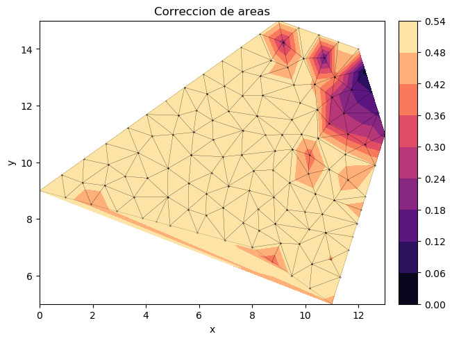

```python
areas = areaCorrection(ModeloL,errores,K=0.002, alpha=1,area0=0.5,plot=True)
areasR = areasRefinado(ModeloL,areas)
```

### Paso 6: Resultado final y datos

Se modifica el atributo 'triangle_max_area' de las triangulaciones de *Triangle* para que tenga en dicha correccion de area. Posteriormente se genera una nueva triangulacion refinando la triangulacion anterior con las nuevas areas

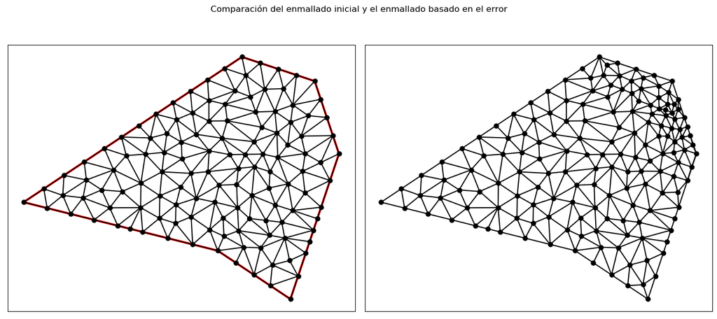

```python
ModeloL.geometria.triangular['triangle_max_area']=np.array(areasR).reshape([len(areasR),1])
tnueva = tr.triangulate(ModeloL.geometria.triangular,'ra')

tr.compare(plt,ModeloL.geometria.triangular,tnueva,figsize=[14,7])
plt.suptitle('Comparación del enmallado inicial y el enmallado basado en el error\n')
```

Posteriormente se guarda una imagen de la triagulación inicial y la triangulacion corregida junto con los datos propuestos por el paper en un archivo de texto separado por comas .csv

```python
#Funcion que genera la matriz de datos propuestos
def extraerFilas(modelo):
    m = []
    for e in modelo.elementos:
        coordsModelo = modelo.geometria.original['vertices'].flatten().tolist()
        cx = [np.average(e.coords[:,0])]
        cy = [np.average(e.coords[:,1])]
        coords = e.coords.flatten().tolist()
        cb = [np.any(np.isin(e.gdl,np.array(modelo.cbe)[:,0]))*1]
        y = [e.areaOptima]
        fila = coordsModelo+coords+cx+cy+cb+y
        m.append(fila)
    return m
```

```python
plt.savefig('PROBLEMA_TUTORIAL.png')
np.savetxt(PATH + "/PROBLEMA_TUTORIAL.csv", np.array(extraerFilas(ModeloL)), delimiter=",")
plt.close('all')
```

Finalmente el resultado del proceso para una geometria termina en una tabla asi:

```python
data = np.genfromtxt('PROBLEMA_TUTORIAL.csv', delimiter=',')

#En este caso se usará pandas para visualizar la saldia como tabla, sin embargo, esto no es necesario
X1 = 'X1'
X2 = 'Y1'
X3 = 'X2'
X4 = 'Y2'
X5 = 'X2'
X6 = 'Y3'
X7 = 'X4'
X8 = 'Y4'
X9 = 'X5'
X10 = 'Y5'
X11 = 'X6'
X12 = 'Y6'
X13 = 'CX'
X14 = 'CY'
X15 = 'XE1'
X16 = 'YE1'
X17 = 'XE2'
X18 = 'YE2'
X19 = 'XE3'
X20 = 'YE3'
X21 = 'CB'
Y = 'A'
columns = [X1,X2,X3,X4,X5,X6,X7,X8,X9,X10,X11,X12,X13,X14,X15,X16,X17,X18,X19,X20,X21,Y]
pd.DataFrame(data, columns=columns).head(10)
```

|  | X1 | Y1 | X2 | Y2 | X2 | Y3 | X4 | Y4 | X5 | Y5 | ... | CX | CY | XE1 | YE1 | XE2 | YE2 | XE3 | YE3 | CB | A |
| --- | --- | --- | --- | --- | --- | --- | --- | --- | --- | --- | --- | --- | --- | --- | --- | --- | --- | --- | --- | --- | --- |
| 0 | 12.0 | 14.0 | 9.0 | 15.0 | 0.0 | 9.0 | 8.0 | 7.0 | 11.0 | 5.0 | ... | 4.823974 | 8.778262 | 4.910428 | 7.772393 | 5.598997 | 8.338225 | 5.111133 | 8.296293 | 0.0 | 0.500000 |
| 1 | 12.0 | 14.0 | 9.0 | 15.0 | 0.0 | 9.0 | 8.0 | 7.0 | 11.0 | 5.0 | ... | 3.549954 | 8.768948 | 2.448015 | 9.181228 | 2.910428 | 8.272393 | 2.969466 | 8.740856 | 0.0 | 0.500000 |
| 2 | 12.0 | 14.0 | 9.0 | 15.0 | 0.0 | 9.0 | 8.0 | 7.0 | 11.0 | 5.0 | ... | 0.832050 | 9.554700 | 0.970143 | 8.757464 | 1.616149 | 9.279939 | 1.139447 | 9.197368 | 1.0 | 0.500000 |
| 3 | 12.0 | 14.0 | 9.0 | 15.0 | 0.0 | 9.0 | 8.0 | 7.0 | 11.0 | 5.0 | ... | 9.315261 | 8.326166 | 9.983802 | 8.250620 | 9.409792 | 9.278793 | 9.569618 | 8.618526 | 0.0 | 0.500000 |
| 4 | 12.0 | 14.0 | 9.0 | 15.0 | 0.0 | 9.0 | 8.0 | 7.0 | 11.0 | 5.0 | ... | 11.607621 | 11.008413 | 10.477726 | 10.852245 | 11.498809 | 10.275249 | 11.194719 | 10.711969 | 0.0 | 0.302270 |
| 5 | 12.0 | 14.0 | 9.0 | 15.0 | 0.0 | 9.0 | 8.0 | 7.0 | 11.0 | 5.0 | ... | 0.832050 | 9.554700 | 0.000000 | 9.000000 | 0.970143 | 8.757464 | 0.600731 | 9.104055 | 1.0 | 0.500000 |
| 6 | 12.0 | 14.0 | 9.0 | 15.0 | 0.0 | 9.0 | 8.0 | 7.0 | 11.0 | 5.0 | ... | 0.970143 | 8.757464 | 1.940285 | 8.514929 | 1.616149 | 9.279939 | 1.508859 | 8.850777 | 0.0 | 0.428978 |
| 7 | 12.0 | 14.0 | 9.0 | 15.0 | 0.0 | 9.0 | 8.0 | 7.0 | 11.0 | 5.0 | ... | 1.940285 | 8.514929 | 2.448015 | 9.181228 | 1.616149 | 9.279939 | 2.001483 | 8.992032 | 0.0 | 0.428978 |
| 8 | 12.0 | 14.0 | 9.0 | 15.0 | 0.0 | 9.0 | 8.0 | 7.0 | 11.0 | 5.0 | ... | 1.616149 | 9.279939 | 2.448015 | 9.181228 | 2.590392 | 9.918824 | 2.218186 | 9.459997 | 0.0 | 0.500000 |
| 9 | 12.0 | 14.0 | 9.0 | 15.0 | 0.0 | 9.0 | 8.0 | 7.0 | 11.0 | 5.0 | ... | 10.359109 | 12.751376 | 10.442734 | 11.861200 | 11.009247 | 12.304376 | 10.603697 | 12.305651 | 0.0 | 0.271180 |

10 rows × 22 columns

## 1.2. Dataset generado

### Uso de Google Colab

Debido ala gran cantidad deoperaciones a realizar en el proceso, se pueden generar los datos usando Google Colab que es una plataformaque permite correr codigo notebooks de Python gratuitamente. En el siguiente link se encuentra el notebook que se usó para generar los datos, se pueden abrir varios notebbols y copiar y pegar el codigo para generar multiples archivos a la vez. link: https://colab.research.google.com/drive/1e_OQSN40kFBsXjevgLn-TVRvN5IH4SQ-?usp=sharing

### Visualización de dataset

```python
#Importar el dataset de la carpeta data
import glob

path_datos = PATH+"/data/*.csv"
datos = []
for filename in glob.glob(path_datos):
    datos+=np.genfromtxt(filename, delimiter=',').tolist()
datos = np.array(datos)
#Creacion del dataset de pandas
dataset = pd.DataFrame.from_records(datos)
dataset.columns = [X1,X2,X3,X4,X5,X6,X7,X8,X9,X10,X11,X12,X13,X14,X15,X16,X17,X18,X19,X20,X21,Y]
dataset.head()
```

|  | X1 | Y1 | X2 | Y2 | X2 | Y3 | X4 | Y4 | X5 | Y5 | ... | CX | CY | XE1 | YE1 | XE2 | YE2 | XE3 | YE3 | CB | A |
| --- | --- | --- | --- | --- | --- | --- | --- | --- | --- | --- | --- | --- | --- | --- | --- | --- | --- | --- | --- | --- | --- |
| 0 | 15.0 | 9.0 | 14.0 | 13.0 | 8.0 | 14.0 | 6.0 | 10.0 | 6.0 | 6.0 | ... | 11.832678 | 7.648313 | 12.223372 | 6.707471 | 12.763857 | 7.127833 | 12.273302 | 7.161206 | 0.0 | 0.161228 |
| 1 | 15.0 | 9.0 | 14.0 | 13.0 | 8.0 | 14.0 | 6.0 | 10.0 | 6.0 | 6.0 | ... | 11.623372 | 5.907471 | 12.600000 | 5.800000 | 12.223372 | 6.707471 | 12.148915 | 6.138314 | 0.0 | 0.165823 |
| 2 | 15.0 | 9.0 | 14.0 | 13.0 | 8.0 | 14.0 | 6.0 | 10.0 | 6.0 | 6.0 | ... | 13.200000 | 6.600000 | 12.763857 | 7.127833 | 12.223372 | 6.707471 | 12.729076 | 6.811768 | 0.0 | 0.161228 |
| 3 | 15.0 | 9.0 | 14.0 | 13.0 | 8.0 | 14.0 | 6.0 | 10.0 | 6.0 | 6.0 | ... | 12.388969 | 11.340364 | 12.244639 | 10.670338 | 13.206494 | 10.690013 | 12.613368 | 10.900238 | 0.0 | 0.191669 |
| 4 | 15.0 | 9.0 | 14.0 | 13.0 | 8.0 | 14.0 | 6.0 | 10.0 | 6.0 | 6.0 | ... | 8.121672 | 6.844932 | 7.972788 | 5.671202 | 8.572046 | 6.356155 | 8.222169 | 6.290763 | 0.0 | 0.148084 |

5 rows × 22 columns

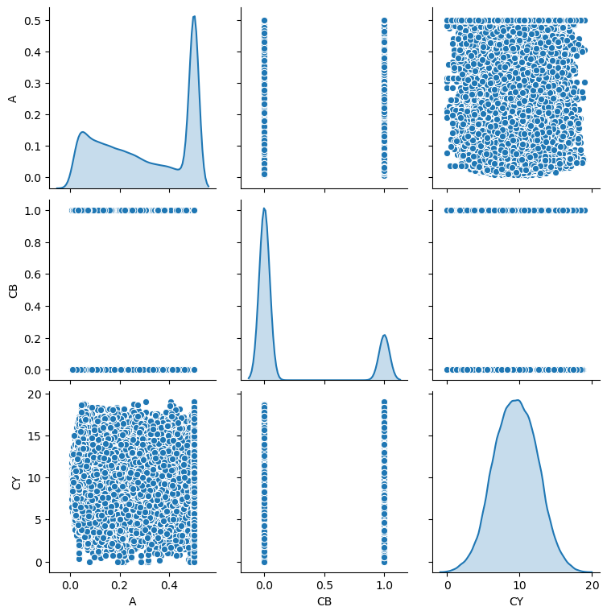

```python
train_dataset = dataset.sample(frac=0.8,random_state=0)
test_dataset = dataset.drop(train_dataset.index)
sns.pairplot(train_dataset[['A','CB','CY']], diag_kind="kde")
```

### Normalización de datos

```python
train_stats = train_dataset.describe()
train_stats.pop("A")
train_stats = train_stats.transpose()
train_labels = train_dataset.pop('A')
test_labels = test_dataset.pop('A')
normed_train_data = norm(train_dataset)
normed_test_data = norm(test_dataset)
```

# 2. Red Neuronal

## 2.1 Generación de ResNet

Usando la API funcional de Keras incluida en TensorFlow, se construyó la red neuronal

```python
def generarResNet(n,tipo):
    """Funcion que retorna el modelo ResNet del paper
    """
    if tipo == 1:
        #Entradas
        inputs = keras.Input(shape=(n), name="Entradas")
        #Bloque 1
        block_1_output = layers.Dense(32, activation="relu", name='Capa_1_32')(inputs)
        x = layers.Dense(32, activation="relu", name='Capa_2_32')(block_1_output)
        x = layers.Dense(64, activation="relu", name='Capa_3_64')(x)
        x = layers.Dense(128, activation="relu", name='Capa_4_128')(x)
        x = layers.Dense(64, activation="relu", name='Capa_5_64')(x)
        x = layers.Dense(32, activation="relu", name='Capa_6_32')(x)
        #Skip Connection
        x = layers.add([block_1_output, x],name='SkipConnection_suma')
        #Bloque 2
        #Salidas
        outputs = layers.Dense(1,activation='relu', name='Capa_7-Salida_1')(x)
        #Modelo completo
        model = keras.Model(inputs, outputs, name="MeshingNet_ResNet")

    elif tipo ==2:
        #Entradas
        inputs = keras.Input(shape=(n), name="Entradas-InicioBloque_1")
        #Bloque 1
        block_1_output = layers.Dense(32, activation="relu", name='Capa_1-FinBloque_1')(inputs)
        x = layers.Dense(32, activation="relu", name='Capa_1-InicioBloque_2')(block_1_output)
        x = layers.Dense(32, activation="relu", name='Capa_2-Bloque_2')(x)
        #Bloque 2
        #Skip Connecection 1
        block_2_output = layers.add([x, block_1_output],name='SkipConnection_1-FinBloque_2')
        x = layers.Dense(32, activation="relu", name='Capa_1-Bloque_3')(block_2_output)
        #Bloque 3
        #Skip Connection 2
        block_3_output = layers.add([block_1_output, block_2_output],name='SkipConnection_2')
        x = layers.Dense(32, activation="relu", name='Capa_1-Bloque_4')(block_3_output)
        #Bloque 4
        #Skip Connection 3
        block_4_output = layers.add([block_1_output, block_3_output],name='SkipConnection_3')
        x = layers.Dense(32, activation="relu", name='Capa_1-InicioBloque_4')(block_4_output)
        x = layers.Dense(32, activation="relu", name='Capa_2-Bloque_4')(x)
        #Salidas
        outputs = layers.Dense(1,activation='relu', name='Capa_3-FinBloque_4')(x)
        #Modelo Completo
        model = keras.Model(inputs, outputs, name="MeshingNet_ResNet2")

    else:
        raise Exception('El tipo de modelo debe ser 1 o 2')
    #Optimizador del modelo
    optimizer = tf.keras.optimizers.Adam()
    model.compile(loss='mse',optimizer=optimizer,metrics=['mae', 'mse'])
    return model
```

## 2.2. Generacion y visualización de red neuronal

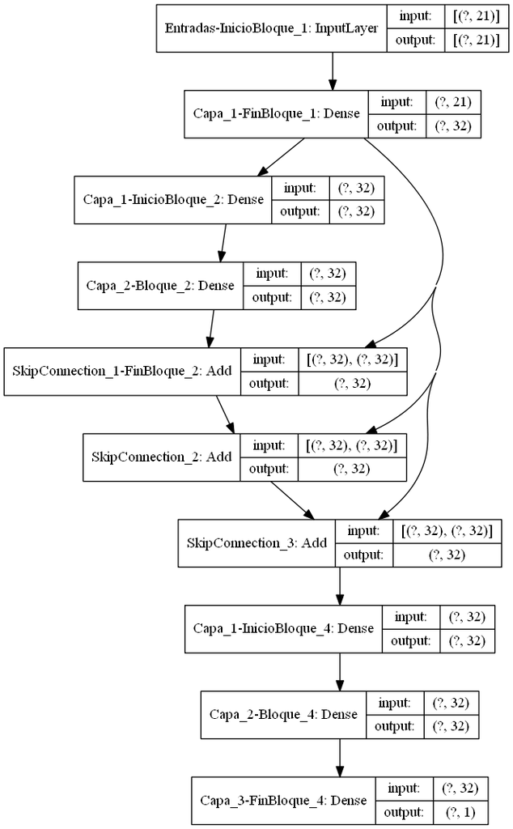

```python
EPOCHS = 1000

n = len(train_dataset.keys())
model = generarResNet(n,tipo=2)
mostrarModelo(model, show_shapes=True)
```

## 2.3. Entrenamiento del modelo

```python
#Entrenamiento
earlyStop = True
## Early Stop
if earlyStop:
    early_stop = keras.callbacks.EarlyStopping(monitor='val_loss', patience=10)

    ## Metodo entrenar
    history = model.fit(
      normed_train_data, train_labels,
      epochs=EPOCHS, validation_split = 0.2, verbose=0,
      callbacks=[early_stop,tfdocs.modeling.EpochDots()])
else:
    ## Metodo entrenar
    history = model.fit(
      normed_train_data, train_labels,
      epochs=EPOCHS, validation_split = 0.2, verbose=1,
      callbacks=[tfdocs.modeling.EpochDots()])
```

```
Epoch: 0, loss:0.0289,  mae:0.1297,  mse:0.0289,  val_loss:0.0144,  val_mae:0.0958,  val_mse:0.0144,
............................................................................................
```

## 2.4. Validación del modelo

### Validation data

|  | loss | mae | mse | val_loss | val_mae | val_mse | epoch |
| --- | --- | --- | --- | --- | --- | --- | --- |
| 87 | 0.003442 | 0.040716 | 0.003442 | 0.003844 | 0.041916 | 0.003844 | 87 |
| 88 | 0.003438 | 0.040644 | 0.003438 | 0.003873 | 0.042118 | 0.003873 | 88 |
| 89 | 0.003445 | 0.040677 | 0.003445 | 0.003844 | 0.042112 | 0.003844 | 89 |
| 90 | 0.003409 | 0.040523 | 0.003409 | 0.003845 | 0.041785 | 0.003845 | 90 |
| 91 | 0.003425 | 0.040555 | 0.003425 | 0.003984 | 0.044076 | 0.003984 | 91 |

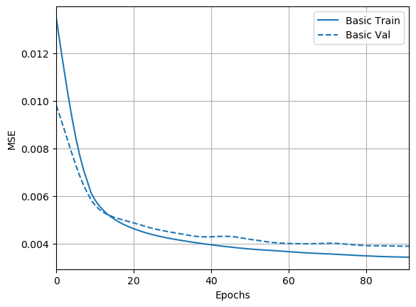

```python
#Estadisticos de validacion
hist = pd.DataFrame(history.history)
hist['epoch'] = history.epoch
plotter = tfdocs.plots.HistoryPlotter(smoothing_std=2)
plotter.plot({'Basic': history}, metric = "mse")
plt.ylabel('MSE')
hist.tail()
```

### Test data

```python
model.evaluate(normed_test_data, test_labels, batch_size=128)
```

```
[0.004204805940389633, 0.04598505422472954, 0.004204805940389633]
```

## 2.5. Pruebas con nuevas geometrías

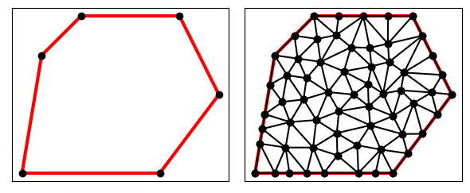

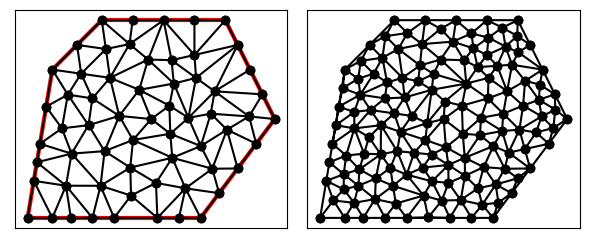

```python
radio=5
points = generatePolygon(2*radio, 2*radio, radio, irregularity=0.5, spikeyness=0.5, numVerts=6)
geometria = Mesh.Delaunay1V(points, 'pDa1',plot=True)
geometria.cbe = geometria.generarCB([0,1],0)
geometria.areaRefiner(model,norm)
```

```
Graficando derivada y [##################################################] 232/232
```

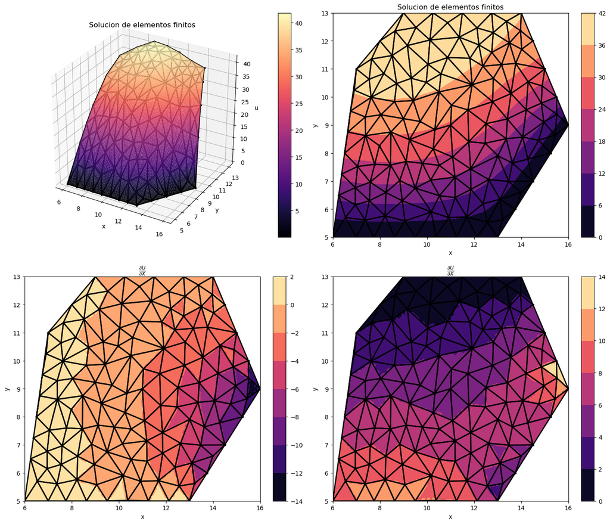

```python
f = FEM.FEM1V(geometria)
f.generarElementos()
a11 = lambda x,y: 1
a12 = lambda x,y: 0
a21 = lambda x,y: 0
a22 = lambda x,y: 1
a00 = lambda x,y: 0
f0 = lambda x,y: 2
f.definirCondicionesDeBorde(geometria.cbe)
f.solucionar(cmap='magma',markersize=1,linewidth=1,a11=a11,a12=a12,a21=a21,a22=a22,a00=a00,f=f0)
```